# ML_Coupons

### Will a Customer Accept the Coupon?

**Context**

Imagine driving through town and a coupon is delivered to your cell phone for a restaraunt near where you are driving. Would you accept that coupon and take a short detour to the restaraunt? Would you accept the coupon but use it on a sunbsequent trip? Would you ignore the coupon entirely? What if the coupon was for a bar instead of a restaraunt? What about a coffee house? Would you accept a bar coupon with a minor passenger in the car? What about if it was just you and your partner in the car? Would weather impact the rate of acceptance? What about the time of day?

Obviously, proximity to the business is a factor on whether the coupon is delivered to the driver or not, but what are the factors that determine whether a driver accepts the coupon once it is delivered to them? How would you determine whether a driver is likely to accept a coupon?

**Overview**

The goal of this project is to use what you know about visualizations and probability distributions to distinguish between customers who accepted a driving coupon versus those that did not.

**Data**

This data comes to us from the UCI Machine Learning repository and was collected via a survey on Amazon Mechanical Turk. The survey describes different driving scenarios including the destination, current time, weather, passenger, etc., and then ask the person whether he will accept the coupon if he is the driver. Answers that the user will drive there ‘right away’ or ‘later before the coupon expires’ are labeled as ‘Y = 1’ and answers ‘no, I do not want the coupon’ are labeled as ‘Y = 0’. There are five different types of coupons -- less expensive restaurants (under \$20), coffee houses, carry out & take away, bar, and more expensive restaurants (\$20 - \$50).

**Deliverables**

Your final product should be a brief report that highlights the differences between customers who did and did not accept the coupons. To explore the data you will utilize your knowledge of plotting, statistical summaries, and visualization using Python. You will publish your findings in a public facing github repository as your first portfolio piece.

### Data Description

Keep in mind that these values mentioned below are average values.

The attributes of this data set include:

1. User attributes
   - Gender: male, female
   - Age: below 21, 21 to 25, 26 to 30, etc.
   - Marital Status: single, married partner, unmarried partner, or widowed
   - Number of children: 0, 1, or more than 1
   - Education: high school, bachelors degree, associates degree, or graduate degree
   - Occupation: architecture & engineering, business & financial, etc.
   - Annual income: less than \$12500, \$12500 - \$24999, \$25000 - \$37499, etc.
   - Number of times that he/she goes to a bar: 0, less than 1, 1 to 3, 4 to 8 or greater than 8
   - Number of times that he/she buys takeaway food: 0, less than 1, 1 to 3, 4 to 8 or greater

   than 8
   - Number of times that he/she goes to a coffee house: 0, less than 1, 1 to 3, 4 to 8 or

   greater than 8
   - Number of times that he/she eats at a restaurant with average expense less than \$20 per

   person: 0, less than 1, 1 to 3, 4 to 8 or greater than 8
   - Number of times that he/she goes to a bar: 0, less than 1, 1 to 3, 4 to 8 or greater than 8
2. Contextual attributes
   - Driving destination: home, work, or no urgent destination
   - Location of user, coupon and destination: we provide a map to show the geographical

   location of the user, destination, and the venue, and we mark the distance between each two places with time of driving. The user can see whether the venue is in the same direction as the destination.
   - Weather: sunny, rainy, or snowy
   - Temperature: 30F, 55F, or 80F
   - Time: 10AM, 2PM, or 6PM
   - Passenger: alone, partner, kid(s), or friend(s)
3. Coupon attributes
   - time before it expires: 2 hours or one day

```python
import matplotlib.pyplot as plt
import seaborn as sns
import pandas as pd
import numpy as np
import plotly.express as px
```

### Problems

Use the prompts below to get started with your data analysis.

1. Read in the `coupons.csv` file.

```python
data = pd.read_csv('data/coupons.csv')
```

```python
data.head()
```

|  | destination | passanger | weather | temperature | time | coupon | expiration | gender | age | maritalStatus | ... | CoffeeHouse | CarryAway | RestaurantLessThan20 | Restaurant20To50 | toCoupon_GEQ5min | toCoupon_GEQ15min | toCoupon_GEQ25min | direction_same | direction_opp | Y |
| --- | --- | --- | --- | --- | --- | --- | --- | --- | --- | --- | --- | --- | --- | --- | --- | --- | --- | --- | --- | --- | --- |
| 0 | No Urgent Place | Alone | Sunny | 55 | 2PM | Restaurant(<20) | 1d | Female | 21 | Unmarried partner | ... | never | NaN | 4~8 | 1~3 | 1 | 0 | 0 | 0 | 1 | 1 |
| 1 | No Urgent Place | Friend(s) | Sunny | 80 | 10AM | Coffee House | 2h | Female | 21 | Unmarried partner | ... | never | NaN | 4~8 | 1~3 | 1 | 0 | 0 | 0 | 1 | 0 |
| 2 | No Urgent Place | Friend(s) | Sunny | 80 | 10AM | Carry out & Take away | 2h | Female | 21 | Unmarried partner | ... | never | NaN | 4~8 | 1~3 | 1 | 1 | 0 | 0 | 1 | 1 |
| 3 | No Urgent Place | Friend(s) | Sunny | 80 | 2PM | Coffee House | 2h | Female | 21 | Unmarried partner | ... | never | NaN | 4~8 | 1~3 | 1 | 1 | 0 | 0 | 1 | 0 |
| 4 | No Urgent Place | Friend(s) | Sunny | 80 | 2PM | Coffee House | 1d | Female | 21 | Unmarried partner | ... | never | NaN | 4~8 | 1~3 | 1 | 1 | 0 | 0 | 1 | 0 |

5 rows × 26 columns

2. Investigate the dataset for missing or problematic data.

**Check For Null Column Values**

```python
data.isnull().sum() #To check null values of columns
```

```
destination                 0
passanger                   0
weather                     0
temperature                 0
time                        0
coupon                      0
expiration                  0
gender                      0
age                         0
maritalStatus               0
has_children                0
education                   0
occupation                  0
income                      0
car                     12576
Bar                       107
CoffeeHouse               217
CarryAway                 151
RestaurantLessThan20      130
Restaurant20To50          189
toCoupon_GEQ5min            0
toCoupon_GEQ15min           0
toCoupon_GEQ25min           0
direction_same              0
direction_opp               0
Y                           0
dtype: int64
```

3. Decide what to do about your missing data -- drop, replace, other...

I'll be dropping the car column given not only it is missing most data but also the data provided is not useful. This data needs to be revisited in the future to also add electric vehicles as that can certainly be a factor for customers to drive a certain location where coupon can be used either to charge a car or if it's on their way. For now, this column is useless and will drop it.

The other columns values needs to be filled using existing values.

```python
data.drop('car', axis=1, inplace=True) #To drop car column. Here axis 1 is Column.
```

**Filling Missing Values** Using fillna method in Pandas, this will add missing values based on the data that is currently available to us. Below is the code for the same.

```python
#Fill Missing Values using fillna
data['Bar']=data['Bar'].fillna(data['Bar'].value_counts().index[0]) #Fill missing Bar Values
data['CoffeeHouse']=data['CoffeeHouse'].fillna(data['CoffeeHouse'].value_counts().index[0]) #Fill missing CoffeeHouse Values
data['CarryAway']=data['CarryAway'].fillna(data['CarryAway'].value_counts().index[0]) #Fill missing CarryAway Values
data['RestaurantLessThan20']=data['RestaurantLessThan20'].fillna(data['RestaurantLessThan20'].value_counts().index[0]) #Fll missing Restaurant Values
data['Restaurant20To50']=data['Restaurant20To50'].fillna(data['Restaurant20To50'].value_counts().index[0])
```

```python
#After dropping car column and filling missing values, we see there is no null data in the dataframe
data.isnull().sum()
```

```
destination             0
passanger               0
weather                 0
temperature             0
time                    0
coupon                  0
expiration              0
gender                  0
age                     0
maritalStatus           0
has_children            0
education               0
occupation              0
income                  0
Bar                     0
CoffeeHouse             0
CarryAway               0
RestaurantLessThan20    0
Restaurant20To50        0
toCoupon_GEQ5min        0
toCoupon_GEQ15min       0
toCoupon_GEQ25min       0
direction_same          0
direction_opp           0
Y                       0
dtype: int64
```

4. What proportion of the total observations chose to accept the coupon?

```
Y
1    56.843267
0    43.156733
Name: proportion, dtype: float64
```

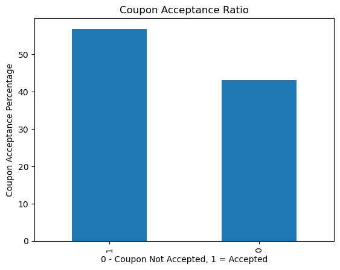

```python
Coupon_Accepted = data['Y'].value_counts(normalize=True) * 100 #Get the Values in Percentage and assigns it to Variable
Coupon_Accepted.plot(kind = 'bar') #Bar plot based on Variable values using Pandas
plt.ylabel('Coupon Acceptance Percentage') #Set the Y-Axis Label
plt.xlabel('0 - Coupon Not Accepted, 1 = Accepted') #Set the X-Axis Label
plt.title('Coupon Acceptance Ratio') #Title of the Bar plot
print (Coupon_Accepted)
```

As you see from above Plots, Nearly 57% of users accepted a coupon.

5. Use a bar plot to visualize the `coupon` column.

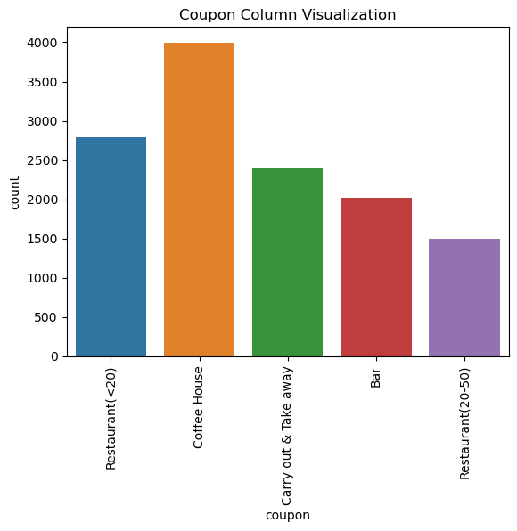

```python
sns.countplot(x='coupon', data=data) #Seaborn Countplot to Visualize Coupon Column
plt.xticks(rotation=90) #To rotate X-Axis Values to 90. This will make them vertical and not overlap with each other
plt.title("Coupon Column Visualization") #Title of the plot.
```

6. Use a histogram to visualize the temperature column.

```python
px.histogram(data, x="temperature", color="coupon", title="Histogram Visualization of Temperature Column") #Using plotly to Visualize temperature column along wiht types of Coupons accepted
```

[interactive chart not shown]

**Investigating the Bar Coupons**

Now, we will lead you through an exploration of just the bar related coupons.

1. Create a new `DataFrame` that contains just the bar coupons.

```python
#Creating new dataframe called barframe and selecting only Bar Coupon
barframe = data.loc[data['coupon'] == 'Bar']
```

```python
barframe.head() #Getting 1st 5 rows of barframe
```

|  | destination | passanger | weather | temperature | time | coupon | expiration | gender | age | maritalStatus | ... | CoffeeHouse | CarryAway | RestaurantLessThan20 | Restaurant20To50 | toCoupon_GEQ5min | toCoupon_GEQ15min | toCoupon_GEQ25min | direction_same | direction_opp | Y |
| --- | --- | --- | --- | --- | --- | --- | --- | --- | --- | --- | --- | --- | --- | --- | --- | --- | --- | --- | --- | --- | --- |
| 9 | No Urgent Place | Kid(s) | Sunny | 80 | 10AM | Bar | 1d | Female | 21 | Unmarried partner | ... | never | 1~3 | 4~8 | 1~3 | 1 | 1 | 0 | 0 | 1 | 0 |
| 13 | Home | Alone | Sunny | 55 | 6PM | Bar | 1d | Female | 21 | Unmarried partner | ... | never | 1~3 | 4~8 | 1~3 | 1 | 0 | 0 | 1 | 0 | 1 |
| 17 | Work | Alone | Sunny | 55 | 7AM | Bar | 1d | Female | 21 | Unmarried partner | ... | never | 1~3 | 4~8 | 1~3 | 1 | 1 | 1 | 0 | 1 | 0 |
| 24 | No Urgent Place | Friend(s) | Sunny | 80 | 10AM | Bar | 1d | Male | 21 | Single | ... | less1 | 4~8 | 4~8 | less1 | 1 | 0 | 0 | 0 | 1 | 1 |
| 35 | Home | Alone | Sunny | 55 | 6PM | Bar | 1d | Male | 21 | Single | ... | less1 | 4~8 | 4~8 | less1 | 1 | 0 | 0 | 1 | 0 | 1 |

5 rows × 25 columns

2. What proportion of bar coupons were accepted?

```
Y
0    58.998513
1    41.001487
Name: proportion, dtype: float64
```

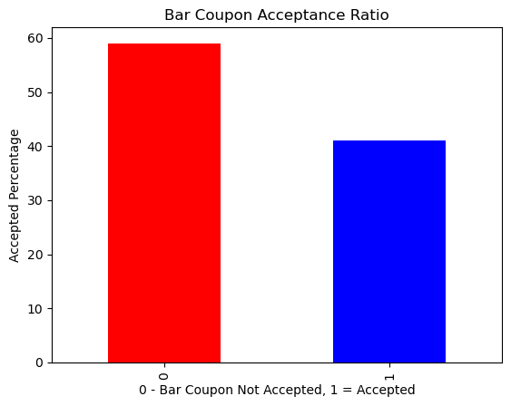

```python
Accepted = barframe['Y'].value_counts(normalize=True) * 100 #Get the Values in Percentage and assigns it to Accepted Variable
colors = ['red', 'blue'] #Assign a different color to each bar
Accepted.plot(kind = 'bar', color=colors) #Bar plot based on Accepted Variable values using Pandas
plt.ylabel('Accepted Percentage') #Set the Y-Axis Label
plt.xlabel('0 - Bar Coupon Not Accepted, 1 = Accepted') #Set the X-Axis Label
plt.title('Bar Coupon Acceptance Ratio') #Title of the Bar plot
Accepted #Uncomment to display percentage values
```

3. Compare the acceptance rate between those who went to a bar 3 or fewer times a month to those who went more.

```
Y
0    62.926293
1    37.073707
Name: proportion, dtype: float64
```

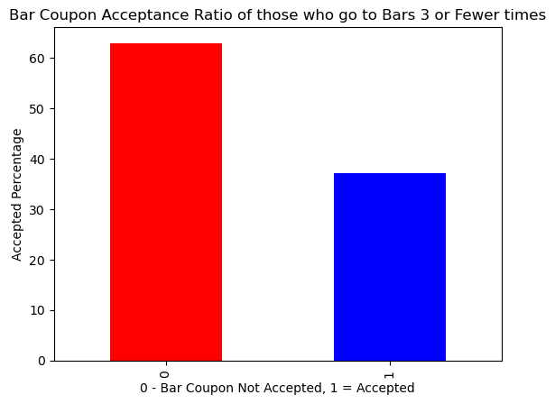

```python
fewer = ['1~3','less1','never']
barplot = barframe.loc[(barframe['Bar'].isin(fewer))] #USe loc to select only a subset of values from a column
barplot = barplot['Y'].value_counts(normalize=True) * 100 #Calculate Acceptance Rate
barplot.plot(kind ='bar', color=colors) #Plot the Graph
plt.ylabel('Accepted Percentage') #Set the Y-Axis Label
plt.xlabel('0 - Bar Coupon Not Accepted, 1 = Accepted') #Set the X-Axis Label
plt.title('Bar Coupon Acceptance Ratio of those who go to Bars 3 or Fewer times') #Title of the Bar plot
barplot #Display % Value
```

4. Compare the acceptance rate between drivers who go to a bar more than once a month and are over the age of 25 to the all others. Is there a difference?

```python
import warnings
warnings.filterwarnings('ignore')
#Converting Age to numeric values, Change 50plus to 51 and below 21 to 20
barframe['age'] = barframe['age'].apply(lambda v: 51 if v == '50plus' else (20 if v=='below21' else v))
```

```python
#Converting age column to type int64
barframe['age'] = barframe['age'].astype('int64')
```

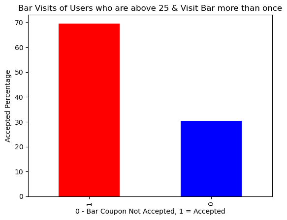

```python
barvisits = ['gt8', '4~8', '1~3'] #Filter Bar visists based on criteria
above25 = barframe.loc[(barframe['age'] > 25) & (barframe['Bar'].isin(barvisits))] #Assign to a variable with appropriate conditions
above25 = above25['Y'].value_counts(normalize=True) * 100 #Calculate Percentage based on above conditions
above25.plot(kind ='bar', color=colors)
above25
plt.ylabel('Accepted Percentage') #Set the Y-Axis Label
plt.xlabel('0 - Bar Coupon Not Accepted, 1 = Accepted') #Set the X-Axis Label
plt.title('Bar Visits of Users who are above 25 & Visit Bar more than once') #Title of the Bar plot
#plt.xlabel('Coupon Acceptance')
```

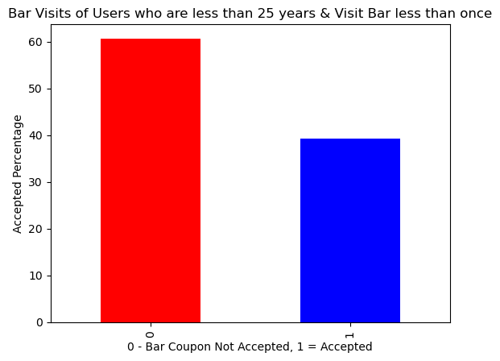

```python
barless = ['less1', 'never'] #Filter Bar visists based on criteria
less25 = barframe.loc[(barframe['age'] < 25) & (barframe['Bar'].isin(barless))] #Assign to a variable with appropriate conditions
less25 = less25['Y'].value_counts(normalize=True) * 100 #Calculate Percentage based on above conditions
less25.plot(kind ='bar', color=colors)
less25
plt.ylabel('Accepted Percentage') #Set the Y-Axis Label
plt.xlabel('0 - Bar Coupon Not Accepted, 1 = Accepted') #Set the X-Axis Label
plt.title('Bar Visits of Users who are less than 25 years & Visit Bar less than once') #Title of the Bar plot
#plt.xlabel('Coupon Acceptance')
```

People who are above 25 and frequent visitors, have acceptance rate of nearly 70% as compared to 40% acceptance rate of users who are below 25 and visit bar less often

5. Use the same process to compare the acceptance rate between drivers who go to bars more than once a month and had passengers that were not a kid and had occupations other than farming, fishing, or forestry.

```
Y
1    71.324864
0    28.675136
Name: proportion, dtype: float64
```

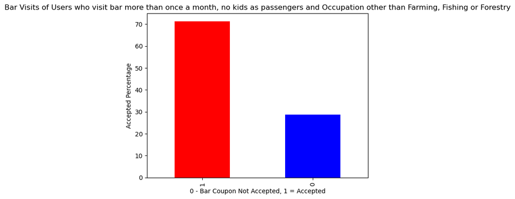

```python
ans5 = barframe.loc[(barframe['passanger'] != 'Kid(s)') & (barframe['occupation'] != 'Farming Fishing & Forestry') &  (barframe['Bar'].isin(barvisits))]
ans5 = ans5['Y'].value_counts(normalize=True) * 100
ans5.plot(kind = 'bar', color = colors)
plt.ylabel('Accepted Percentage') #Set the Y-Axis Label
plt.xlabel('0 - Bar Coupon Not Accepted, 1 = Accepted') #Set the X-Axis Label
plt.title('Bar Visits of Users who visit bar more than once a month, no kids as passengers and Occupation other than Farming, Fishing or Forestry') #Title of the Bar plot
ans5
```

6. Compare the acceptance rates between those drivers who:
- go to bars more than once a month, had passengers that were not a kid, and were not widowed *OR*
- go to bars more than once a month and are under the age of 30 *OR*
- go to cheap restaurants more than 4 times a month and income is less than 50K.

```
Y
1    58.891753
0    41.108247
Name: proportion, dtype: float64
```

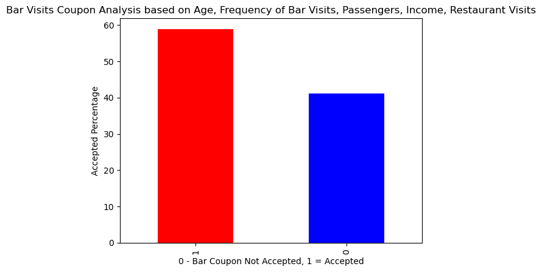

```python
CheapRestaurant = ['4~8', 'gt8'] #Filter Frequency of Cheap Restaurants
IncomeCond = ['$37500 - $49999', '$12500 - $24999', '$25000 - $37499', 'Less than $12500'  ] #Filter by Income
Condition = barframe.loc[((barframe['age'] < 30) & (barframe['Bar'].isin(barvisits))) | ((barframe['passanger'] != 'Kid(s)') & (barframe['maritalStatus'] != 'Widowed') &  (barframe['Bar'].isin(barvisits))) | ((barframe['income'].isin(IncomeCond)) & (barframe['RestaurantLessThan20'].isin(CheapRestaurant))) ] #Assign to a variable with appropriate conditions
Result = Condition['Y'].value_counts(normalize=True) * 100
barplot = Result.plot(kind ='bar', color=colors)
plt.ylabel('Accepted Percentage') #Set the Y-Axis Label
plt.xlabel('0 - Bar Coupon Not Accepted, 1 = Accepted') #Set the X-Axis Label
plt.title('Bar Visits Coupon Analysis based on Age, Frequency of Bar Visits, Passengers, Income, Restaurant Visits') #Title
Result
```

7. Based on these observations, what do you hypothesize about drivers who accepted the bar coupons?

**Observation(s) based on Bar Coupons Findings**

### Independent Investigation

Using the bar coupon example as motivation, you are to explore one of the other coupon groups and try to determine the characteristics of passengers who accept the coupons.

I'll be analyzing expensive Restaurants data as part of my independent investigation.

1. **Compare how expensie Restaurants Coupons Acceptance differ from other Coupons.**

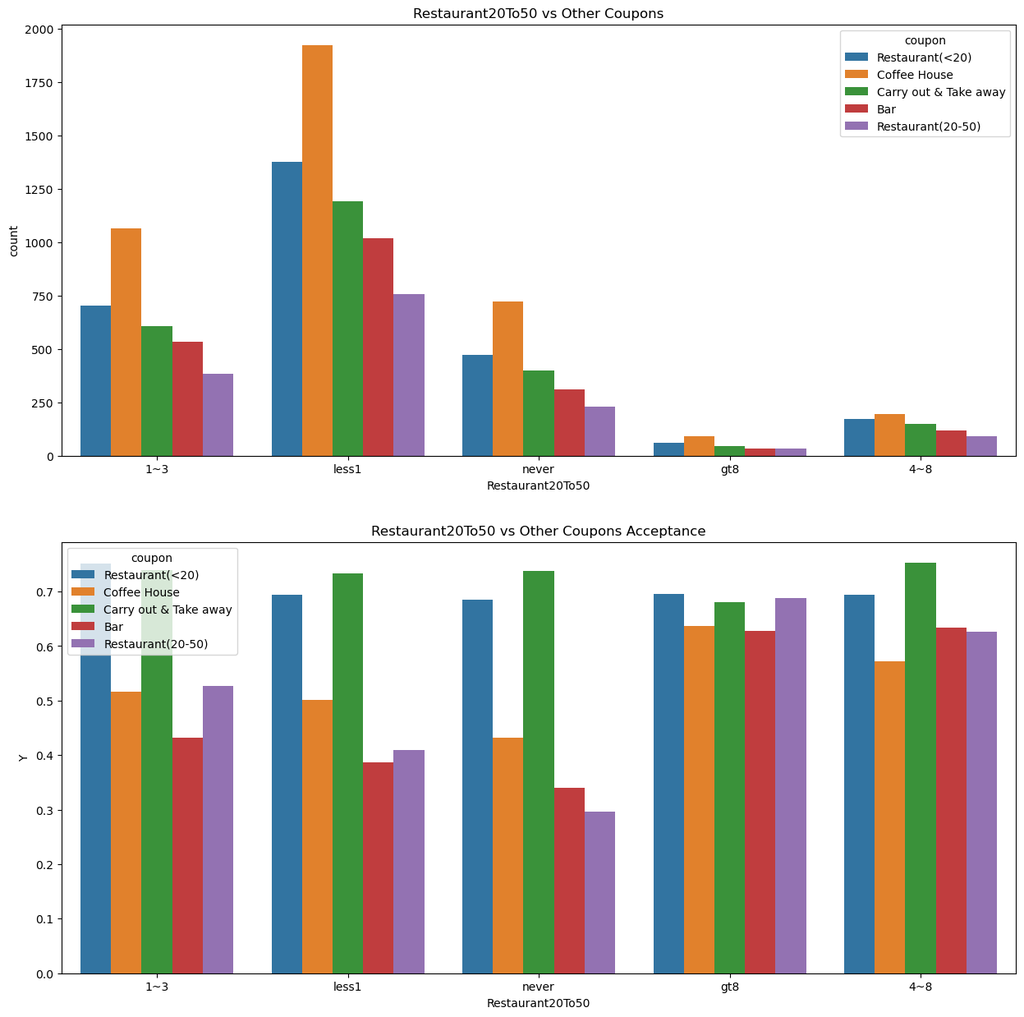

```python
fig,axes = plt.subplots(2, figsize=(15, 15)) #Use Subplots to plot both # of users and also Acceptance Rate
sns.countplot(x=data['Restaurant20To50'],hue=data['coupon'],ax=axes[0]) #Countplot to get count of Coupons
sns.barplot(ax=axes[1], x="Restaurant20To50", y="Y", hue='coupon', ci=None, data=data)
axes[0].set_title('Restaurant20To50 vs Other Coupons'); axes[1].set_title('Restaurant20To50 vs Other Coupons Acceptance')
```

```python
#Creating Restaurant20-50 Coupon dataframe
restaurant = data.loc[data['coupon'] == 'Restaurant(20-50)']
```

2. **Acceptance Rate among users who visit Restaurants on a monthly basis**

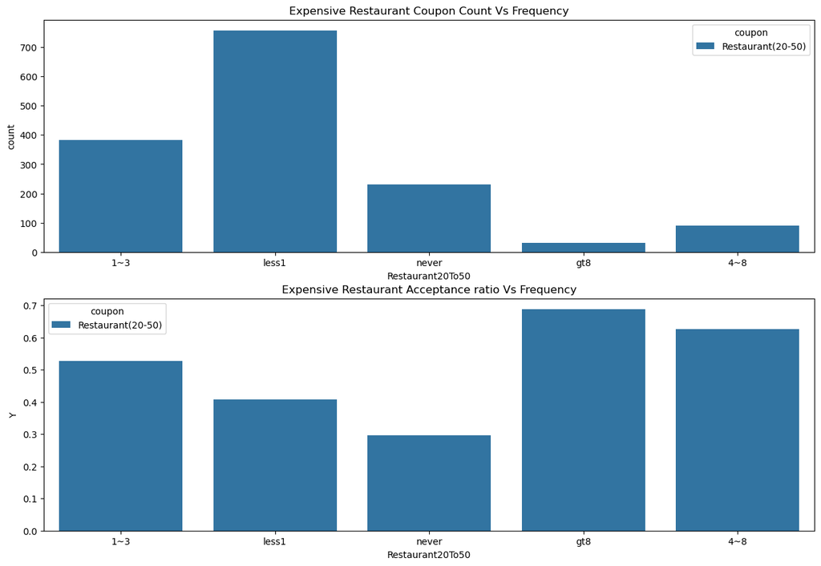

```python
fig,axes = plt.subplots(2, figsize=(15, 10))
sns.countplot(x=restaurant['Restaurant20To50'],hue=restaurant['coupon'],ax=axes[0])
sns.barplot(ax=axes[1], x="Restaurant20To50", y="Y", hue='coupon', ci=None, data=restaurant)
axes[0].set_title('Expensive Restaurant Coupon Count Vs Frequency'); axes[1].set_title('Expensive Restaurant Acceptance ratio Vs Frequency') #Title of both subplots
```

**Observation:** There is a strong correlation among users visting restaurants Vs Coupon Acceptance Rate

3. **Does Destination Direction impact the Acceptance Ratio**

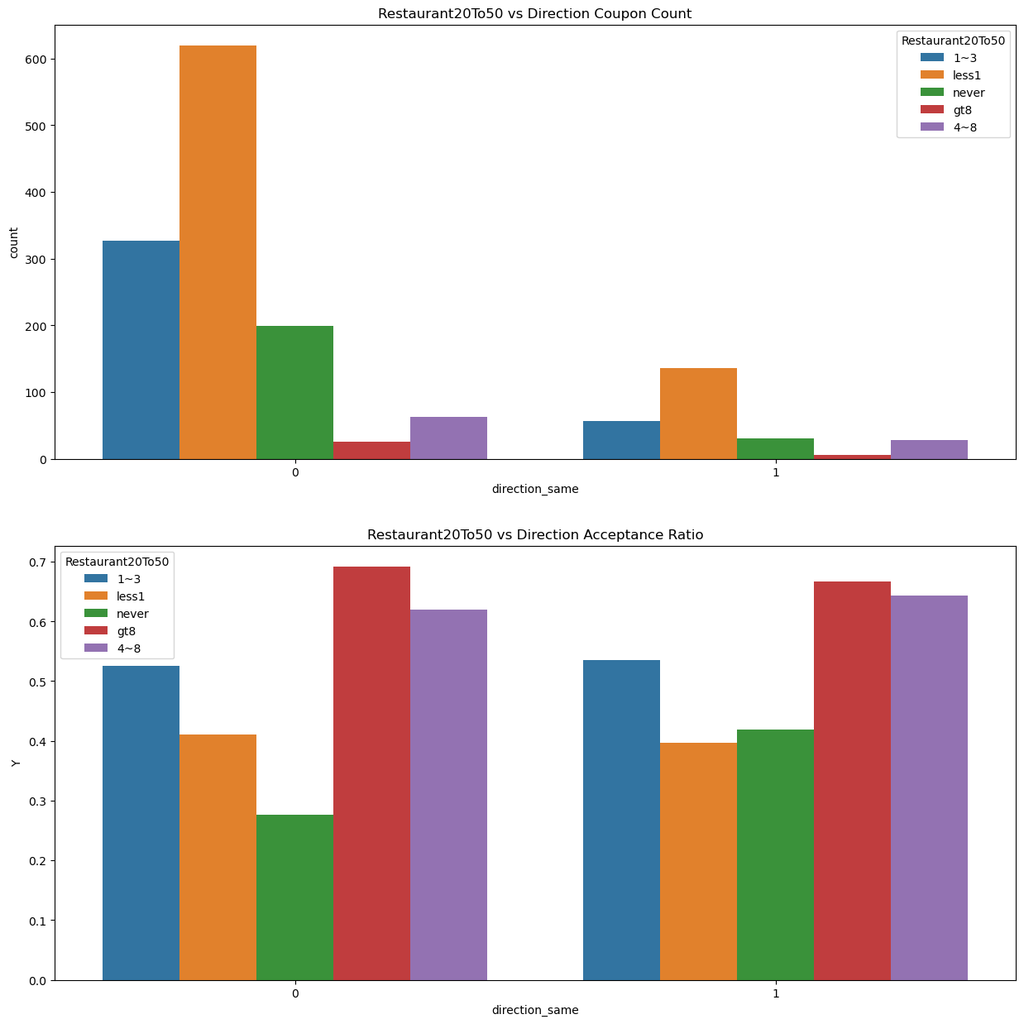

```python
fig,axes = plt.subplots(2, figsize=(15, 15))
sns.countplot(x=restaurant['direction_same'],hue=restaurant['Restaurant20To50'],ax=axes[0])
sns.barplot(ax=axes[1], x="direction_same", y="Y", hue='Restaurant20To50', ci=None, data=restaurant)
#plt.xticks(rotation=90)
axes[0].set_title('Restaurant20To50 vs Direction Coupon Count');axes[1].set_title('Restaurant20To50 vs Direction Acceptance Ratio')
```

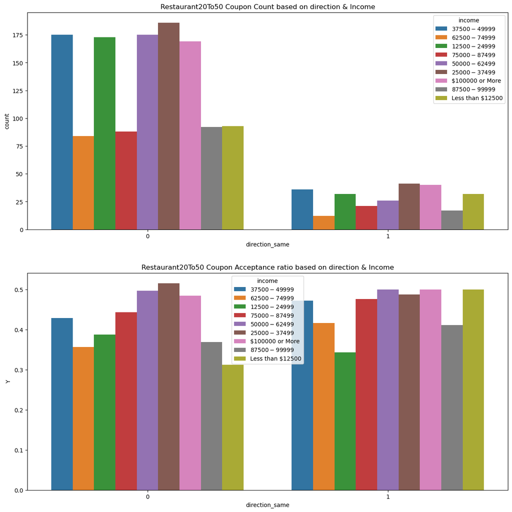

```python
fig,axes = plt.subplots(2, figsize=(15, 15))
sns.countplot(x=restaurant['direction_same'],hue=restaurant['income'],ax=axes[0]) #Acceptance based on direction & Income
sns.barplot(ax=axes[1], x="direction_same", y="Y", hue=restaurant['income'], ci=None, data=restaurant)
axes[0].set_title('Restaurant20To50 Coupon Count based on direction & Income');axes[1].set_title('Restaurant20To50 Coupon Acceptance ratio based on direction & Income') #Set Title
```

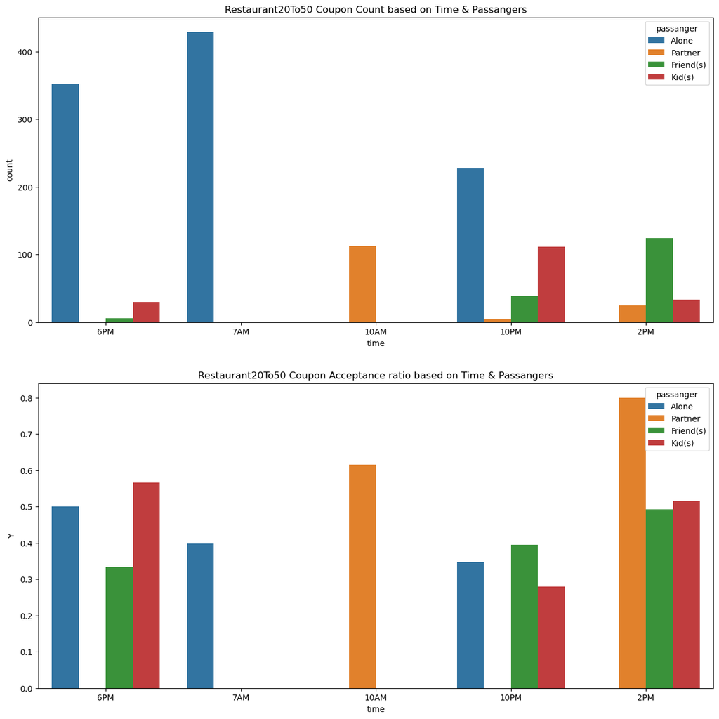

```python
fig,axes = plt.subplots(2, figsize=(15, 15))
sns.countplot(x=restaurant['time'],hue=restaurant['passanger'],ax=axes[0]) #Acceptance based on direction & Income
sns.barplot(ax=axes[1], x="time", y="Y", hue=restaurant['passanger'], ci=None, data=restaurant)
axes[0].set_title('Restaurant20To50 Coupon Count based on Time & Passangers');axes[1].set_title('Restaurant20To50 Coupon Acceptance ratio based on Time & Passangers') #Set Title
```

# Resaurant 20-50 Observation(s) and Target Audience

# Scope & Next Steps:

This Analysis and Visualizations in the notebook are limited to Bar & Restaurant 20-50 Coupons only and have taken into account drivers frequency to visit a bar or a restaurant on a monthly basis, time of travel and the Company they are traveling with.

Next Steps are to take into account other factors like Temperature, Income & compare with other Coupons like Carry Away, Coffee house and Cheap restaurants.

This is the Conclusion of this notebook. Any feedback/suggestions are highly recommended